# Regression and Model Trees

Maggy Critchlow

2/17/2021

## Data and Required Packages

```r
library(tidyverse)
library(caret)
library(rpart)
library(Cubist)
library(visNetwork)
library(sparkline)
growth <- read_csv("GrowthTempWater.csv")
head(growth)
```

```
## # A tibble: 6 x 4
##   Date       Growth  Temp SoilWater
##   <date>      <dbl> <dbl>     <dbl>
## 1 2018-10-01  0.725 0.289     0.660
## 2 2018-10-02  0.907 0.349     0.602
## 3 2018-10-03  0.867 0.367     0.944
## 4 2018-10-04  0.956 0.454     0.939
## 5 2018-10-05  0.711 0.245     0.652
## 6 2018-10-06  0.765 0.266     0.527
```

This data set has information on four variables (growth, temperature, and soil water amount) available over the course of the year. The goal is to find out if the data can be split using either model trees or regression trees.

## Data Visualization

Before running these algorithms, it would be interesting to take a look at the data via some plots.

### Growth and Temperature

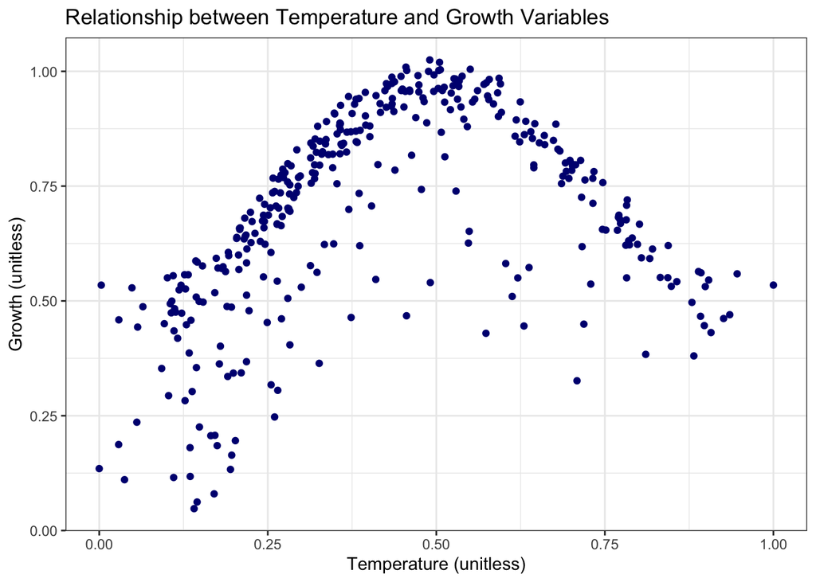

```r
plot1 <- ggplot() + geom_point(data = growth, aes(x = Temp, y = Growth), color = "navy") + theme_bw() + labs(title = "Relationship between Temperature and Growth Variables", x = "Temperature (unitless)", y = "Growth (unitless)")
plot1
```

Whoa, this looks cool. There’s definitely a Goldilocks zone for growth - too hot or too cold is bad for plants. Not surprising, but still interesting to see in plot form. It looks like a pretty strong pattern too - not a lot of scatter around the line (parabola? It’s been a bit since I took algebra).

### Growth and Soil Water

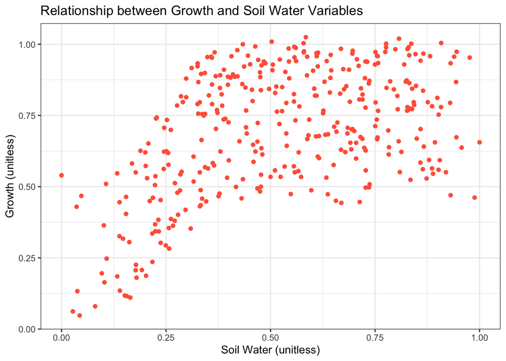

```r
plot2 <- ggplot() + geom_point(data = growth, aes(x = SoilWater, y = Growth), color = "tomato") + theme_bw() + labs(title = "Relationship between Growth and Soil Water Variables", x = "Soil Water (unitless)", y = "Growth (unitless)")
plot2
```

This looks like a decently positive correlation. It’s quite obvious that growth increases with soil water, but only up to a point. More water doesn’t automatically equal more growth.

### Soil Water and Temperature

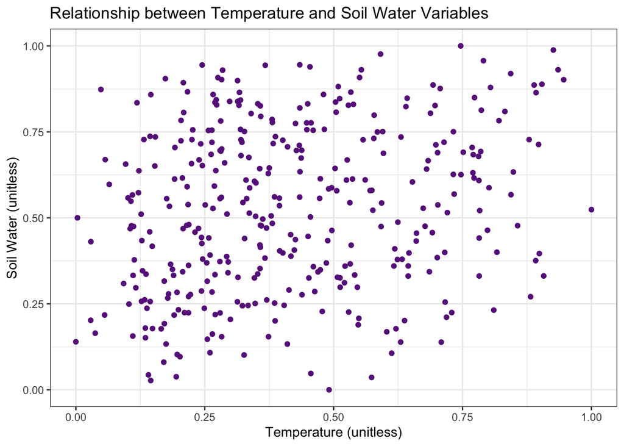

```r
plot3 <- ggplot() + geom_point(data = growth, aes(x = Temp, y = SoilWater), color = "darkorchid4") + theme_bw() + labs(title = "Relationship between Temperature and Soil Water Variables", x = "Temperature (unitless)", y = "Soil Water (unitless)")
plot3
```

This doesn’t look like much of anything to me. Maybe because this data set is from a tropical rainforest, where by definition, rain is pretty consistent? I’m not entirely sure, but the plots on the assigment page don’t show much of a fluctuation in precipitation over the course of the year.

### Growth and Date

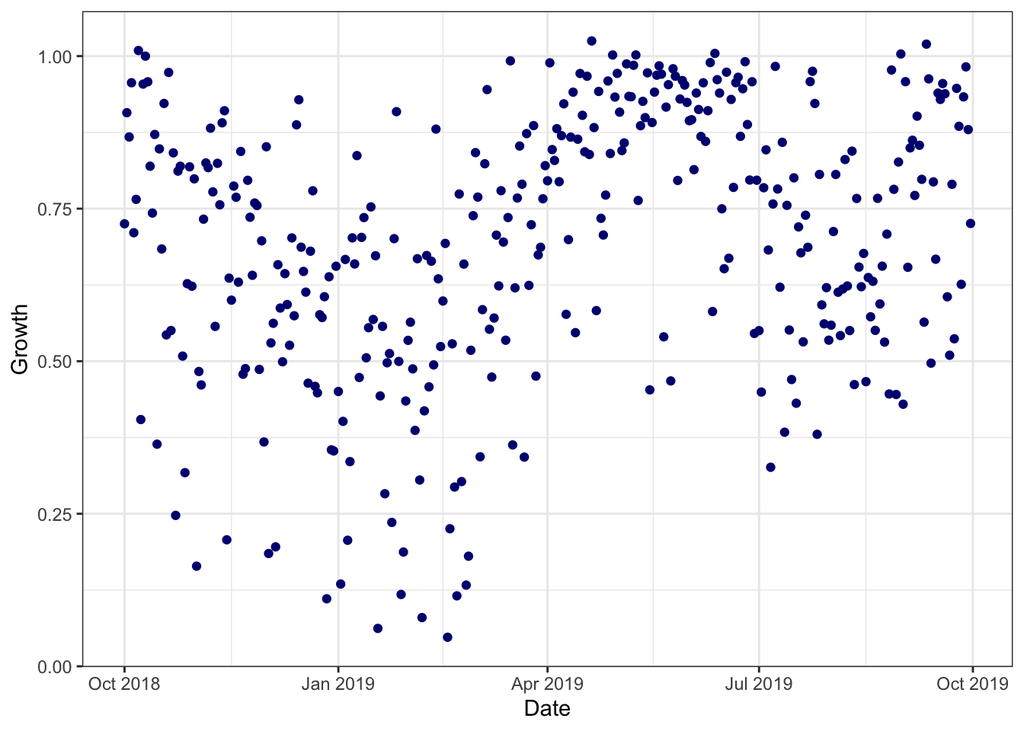

```r
plot4 <- ggplot() + geom_point(data = growth, aes(x = Date, y = Growth), color = "navy") + theme_bw()
plot4
```

My first observation from this plot is that it’s not a great way to visualize a time series relationship, but on the bright side, I’ll be able to learn a lot from the time series class coming up. There might be some relationship between the date and tree growth. Temperature seems like a lot stronger of a predictor, and probably correlates well with date. I’ll keep this in mind.

## Linear Model

Because cross validation is king, I’m going to run this model using `caret` and leave one out cross validation.

```r
# Set up training controls
fitcontrol <- trainControl(method = "LOOCV", number = 365)
# Run model
lm.growth <- train(Growth ~ ., data = growth, method = "lm", trControl = fitcontrol)
lm.growth
```

```
## Linear Regression
##
## 365 samples
##   3 predictor
##
## No pre-processing
## Resampling: Leave-One-Out Cross-Validation
## Summary of sample sizes: 364, 364, 364, 364, 364, 364, ...
## Resampling results:
##
##   RMSE       Rsquared   MAE
##   0.1855962  0.2832345  0.152881
##
## Tuning parameter 'intercept' was held constant at a value of TRUE
```

```r
# Save relevant model statistics to data frame for later use
lm.stats <- lm.growth$results
```

Using all of the predictors, this seems like an okay model. R<sup>2</sup> is not particularly high, and there’s some noise in the model from the RMSE and MAE values. Maybe it would be improved if I removed date as a predictor. Out of curiosity, I ran the model with just `SoilWater` and `Temp` as predictors, but the results didn’t budge. Interesting.

## Regression Tree

Next up is the regression tree, which will split this continuous data into groups. Oddly enough, there is no regression to be found here despite the name. As above, I’ll use the `caret` package to run LOOCV.

```r
rpart.growth <- train(Growth ~ ., data = growth, method = "rpart", trControl = fitcontrol)
rpart.growth
```

```
## CART
##
## 365 samples
##   3 predictor
##
## No pre-processing
## Resampling: Leave-One-Out Cross-Validation
## Summary of sample sizes: 364, 364, 364, 364, 364, 364, ...
## Resampling results across tuning parameters:
##
##   cp         RMSE       Rsquared     MAE
##   0.1302188  0.1543811  0.519644503  0.1297176
##   0.1480407  0.1812732  0.331491447  0.1506126
##   0.4145173  0.2488143  0.004760975  0.2223092
##
## RMSE was used to select the optimal model using the smallest value.
## The final value used for the model was cp = 0.1302188.
```

To be quite honest, I’m still not sure I understand what the “cp” column represents. It looks like the lowest one has the lowest RMSE and MAE, and highest R<sup>2</sup> value. We can also take a look at the visualized regression tree.

```r
visTree(rpart.growth$finalModel)
```

[interactive chart not shown]

Interesting, but maybe unsurprising, temperature is very important for determining growth, although it doesn’t look like the “Goldilocks pattern” holds as much here. Following that, a higher soil water represents a larger growth, with low temperatures and low available water faring the worst. It’d be interesting to find out if regression trees can have more than 2 branches at a node, as maybe a middle range of temperatures would have higher growth.

## Model Trees

Unlike regression trees, model trees do use regression. Linear regression is used to better account for the residuals in each node. As before, I will use `caret` and LOOCV to run this model. I was unable to figure out how to include only one model for the output, so it’s a long way to the bottom. Sorry.

```r
mt.growth <- train(Growth ~ ., data = growth, method = "cubist", trControl = fitcontrol)
mt.growth
```

```
## Cubist
##
## 365 samples
##   3 predictor
##
## No pre-processing
## Resampling: Leave-One-Out Cross-Validation
## Summary of sample sizes: 364, 364, 364, 364, 364, 364, ...
## Resampling results across tuning parameters:
##
##   committees  neighbors  RMSE        Rsquared   MAE
##    1          0          0.04229048  0.9628316  0.03406528
##    1          5          0.04033096  0.9665156  0.03239821
##    1          9          0.03998453  0.9670543  0.03219841
##   10          0          0.03983473  0.9670857  0.03185056
##   10          5          0.03934430  0.9680972  0.03172477
##   10          9          0.03873947  0.9690717  0.03126422
##   20          0          0.03839591  0.9693859  0.03087638
##   20          5          0.03801736  0.9700909  0.03068823
##   20          9          0.03742703  0.9710156  0.03037629
##
## RMSE was used to select the optimal model using the smallest value.
## The final values used for the model were committees = 20 and neighbors = 9.
```

```r
# Sorry this part is so long
summary(mt.growth$finalModel)
```

```
##
## Call:
## cubist.default(x = x, y = y, committees = param$committees)
##
##
## Cubist [Release 2.07 GPL Edition]  Wed Feb 17 22:47:41 2021
## ---------------------------------
##
##     Target attribute `outcome'
##
## Read 365 cases (4 attributes) from undefined.data
##
## Model 1:
##
##   Rule 1/1: [91 cases, mean 0.4926556, range 0.04764505 to 0.9578881, est err 0.0336337]
##
##     if
##  Temp <= 0.4557886
##  SoilWater <= 0.4306717
##     then
##  outcome = -0.2264005 + 1.483 SoilWater + 1.371 Temp
##
##   Rule 1/2: [38 cases, mean 0.6927211, range 0.3261801 to 0.9716766, est err 0.0443878]
##
##     if
##  Temp > 0.4557886
##  SoilWater <= 0.3788887
##     then
##  outcome = 1.0408361 + 1.358 SoilWater - 1.163 Temp
##
##   Rule 1/3: [65 cases, mean 0.7046365, range 0.4462887 to 0.9334245, est err 0.0315356]
##
##     if
##  Temp > 0.5951586
##  SoilWater > 0.3788887
##     then
##  outcome = 1.7214871 - 1.283 Temp - 0.067 SoilWater
##
##   Rule 1/4: [133 cases, mean 0.7514247, range 0.4430625 to 1.009155, est err 0.0315133]
##
```

[output cut: 788 more lines]

```
##
##     Average  |error|          0.0302393
##     Relative |error|               0.17
##     Correlation coefficient        0.99
##
##
##  Attribute usage:
##    Conds  Model
##
##    100%    99%    Temp
##     99%    69%    SoilWater
##            11%    Date
##
##
## Time: 0.0 secs
```

So far this one has the best R<sup>2</sup>, RMSE, and MAE values from our trees. It makes sense, since linear regression allows finer control over the residuals and splits than the other techniques. Linear regression performed the worst, which also makes sense since some of the relationships seen in the plots were decidedly not linear. I’m still not really sure what to do with the committees and neighbors information, and how to utilize that within the cross validation framework. But hopefully I’ll be able to learn this. At any rate, it seems like we can effectively use the temperature and available soil water to predict growth of these tropical rainforest trees.